# A formula interface to ggplot

Daniel Kaplan

2016-06-17

# About formulas

Formulas in R — the objects whose notation uses a tilde as in `y ~ x` — provide a compact and easy-to-read description of the relationships among quantities. For example, in base graphics and lattice graphics, a formula can be used to specify the roles that variables are to play in a graphic as in these examples:

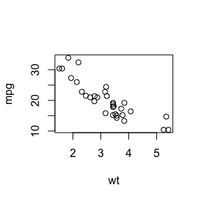

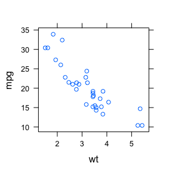

```r
plot(mpg ~ wt, data = mtcars) # base graphics
xyplot(mpg ~ wt, data = mtcars) # lattice graphics
```

Formulas are also used in model-building functions. The response variable appears on the left and explanatory variables on the right. For instance, Figure 2 shows a model built with the recursive partitioning architecture that attempts to account for fuel economy (`mpg`) as a function of engine power (`hp`) and the number of cylinders (`cyl`).

```r
my_model <- rpart(mpg ~ hp + cyl, data = mtcars)
```

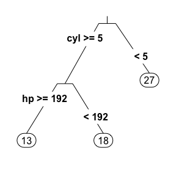

Formulas are used to identify response and explanatory variables in functions to train models.

Although modeling functions such as `lm()`, `glm()`, `rpart()`, etc. have always supported a formula interface, the basic statistical functions in R do not. Using those base functions, it is a multi-step process to do a simple calculation such as calculating the mean of each of multiple groups. The `mosaic` package, designed to streamline R for students (and others!) adds a formula functionality to basic statistical operators, as in these calculation of the mean and standard deviation of `mpg` for cars with different numbers of cylinders.

```r
library(mosaic)
mean(mpg ~ cyl, data = mtcars)
```

```
##        4        6        8
## 26.66364 19.74286 15.10000
```

```r
  sd(mpg ~ cyl, data = mtcars)
```

```
##        4        6        8
## 4.509828 1.453567 2.560048
```

Using this formula interface provides a highly consistent pattern for many different operations in R. Being consistent, it is easier to learn and reinforce that learning.

```r
 median(mpg ~ cyl, data = mtcars)
```

```
##    4    6    8
## 26.0 19.7 15.2
```

```r
     lm(mpg ~ cyl, data = mtcars)
```

```
##
## Call:
## lm(formula = mpg ~ cyl, data = mtcars)
##
## Coefficients:
## (Intercept)          cyl
##      37.885       -2.876
```

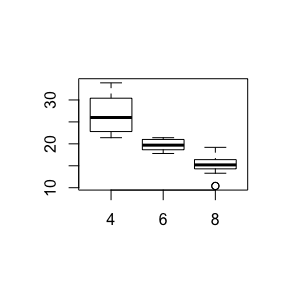

```r
boxplot(mpg ~ cyl, data = mtcars)
```

# ggplot graphics with formulas

*Note: This section does **not** assume a previous knowledge of `ggplot()`.*

The `gf_` series of functions provides formula-based access to several varieties of graphics in the `ggplot` system.

| Function name | graphic type |
| --- | --- |
| `gf_point()` | scatter plot |
| `gf_line()` | similar to scatter plot but points connected |
| `gf_path()` | similar to `gf_line()` but follows the order of points (See examples below.) |
| `gf_density()` | Density plot |
| `gf_histogram()` | Histogram |
| `gf_boxplot()` | Box-and-whiskers plot |
| `gf_bar()` | Bar plot |
| `gf_counts()` | Bar plot of counts |
| `gf_text()` | similar to scatter plot, but with text at each point |

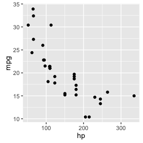

```r
library(statisticalModeling)
gf_point(mpg ~ hp, data = mtcars)
```

Each of the marks in the plot is a *glyph*. Every glyph has graphical *attributes*. In the above plot, the attributes are x- and y-position. Other possible graphical attributes for a point glyph are color, shape, size, stroke, fill, and alpha (transparency).

In the `gf_` functions, you specify the graphical attributes using the formula. Each such specification takes the form `attribute:value`, where `attribute` is one of `color`, `shape`, etc. and `value` is either a constant (e.g. `"red"` or `0.5` as appropriate) or a variable (e.g. `cyl`). For instance:

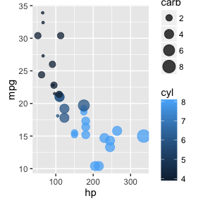

```r
gf_point(mpg ~ hp + color:cyl + size:carb + alpha:0.75, data = mtcars)
```

## Plots of distributions

The ggplot system offers several styles for plotting the distribution of a quantitative variable. These include density, histogram, and frequency polygon in one variable, and contour and shade-encoded density in two variables.

To illustrate, we’ll use the density style `gf_density()`, but the same instructions apply to `gf_histogram()` and `gf_freqpolygon()`. *Note that in the one-variable density graphics, the variable whose density is to be calculated goes to the right of the tilde, in the position reserved for the x-axis variable.*

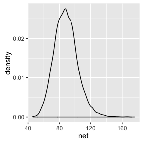

```r
gf_density( ~ net, data = Runners)
```

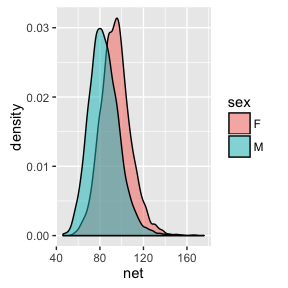

```r
gf_density( ~ net + fill:sex + alpha:0.5, data = Runners)
```

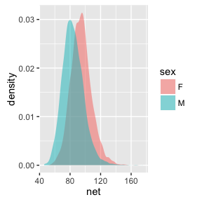

```r
gf_density( ~ net + fill:sex + color:NA + alpha:0.5, data = Runners)
```

When the `fill` or `color` or `group` aesthetics are mapped to a variable, the default behavior is to lay the group-wise densities on top of one another. Other behavior is also available by using `position` in the formula. Using the value `"stack"` causes the densities to be laid one on top of another, so that the overall height of the stack is the density across all groups. The value `"fill"` produces a conditional probability graphic.

```r
gf_density( ~ net + fill:sex + color:NA + position:"stack", data = Runners)
gf_density( ~ net + fill:sex + color:NA + position:"fill", data = Runners)
```

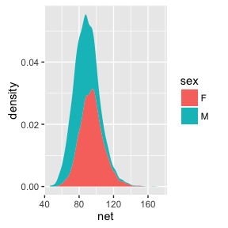

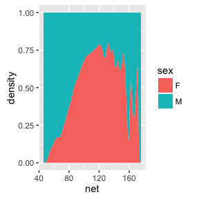

Similar commands can be constructed with `gf_histogram()` and `gf_freqpoly()`, but note that `color`, not `fill`, is the active aesthetic for frequency polygons and `position:"fill"` doesn’t work.

Box and whisker plots show the distribution of a quantitative variable as a function of a categorical variable. The formula used in `gf_boxplot()` should have the quantitative variable to the left of the tilde.

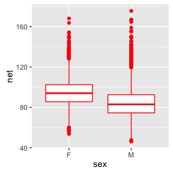

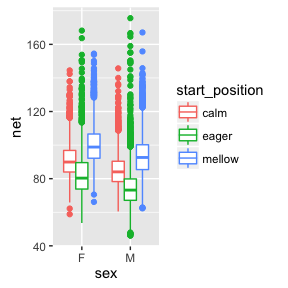

```r
gf_boxplot(net ~ sex + color:"red", data = Runners)
gf_boxplot(net ~ sex + color:start_position, data = Runners)
```

To use a discrete quantitative variable for grouping, you should convert it to a categorical variable. This can be done in several ways:

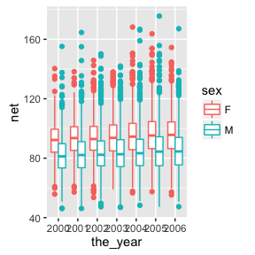

```r
Runners$the_year <- as.character(Runners$year) # in base R
Runners <- Runners %>% mutate(the_year = as.character(year)) # in dplyr
gf_boxplot(net ~ the_year + color:sex, data = Runners)
```

Two-dimensional plots of density also have both a left and right component to the formula.

```r
gf_density_2d(net ~ age, data = Runners)
gf_hex(net ~ age, data = Runners)
```

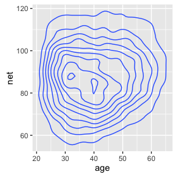

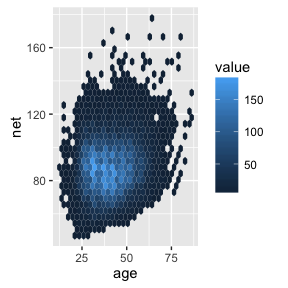

## Paths and lines

The `ggplot` system offers two ways to connect points. `gf_line()` ignores the order of the points in the data draws the line going from left to right. `gf_path()` goes from point to point according to the order in the data. Both forms can use a `color` or `group` aesthetic as a flag to draw groupwise lines.

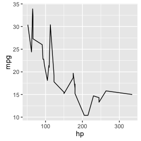

```r
# use a categorical variable
mtcars <- mtcars %>% mutate(n_cylinders = as.character(cyl))
gf_line(mpg ~ hp, data = mtcars)
```

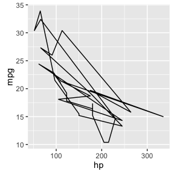

```r
gf_path(mpg ~ hp, data = mtcars)
```

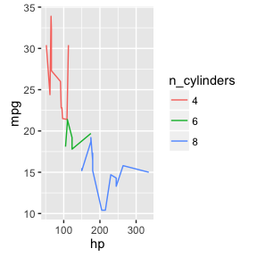

```r
gf_line(mpg ~ hp + color:n_cylinders, data = mtcars)
```

The above are examples of *bad plots*. The viewer is unnecessarily distracted by the zigs and zags in the connecting lines. It would be better to use `gf_point()` here, but then you wouldn’t see how `gf_line()` and `gf_path()` work!

## Faceting

The `ggplot` system allows you to make subplots — called “facets” — based on the values of one or two categorical variables. This is done by “adding” a `facet_grid()` directive. The directive uses a formula to specify which variable(s) are to be used in the grid.

```r
gf_density_2d(net ~ age, data = Runners) + facet_grid( ~ sex)
gf_density_2d(net ~ age, data = Runners) + facet_grid(start_position ~ sex)
```

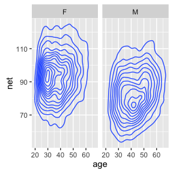

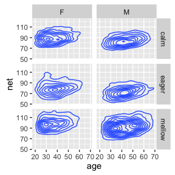

## Overlapping cases

Sometimes you have so many points in a scatter plot that they obscure one another. The `ggplot` system provides two easy ways to deal with this: translucency and jittering.

Use `alpha:0.5` to make the points semi-translucent. If there are many points overlapping at one point, a much smaller value of alpha, say `alpha:0.01`.

Using `gf_jitter()` in place of `gf_point()` will move the plotted points to reduce overlap. You can use both of these techniques, e.g.

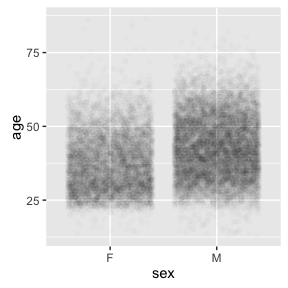

```r
gf_jitter(age ~ sex + alpha:0.01, data = Runners)
```

# gf and gg together

gf generates a ggplot object

Use `verbose = TRUE` to see the string being generated.

# Implementation

formulas don’t allow `=`